# Marketing Analytics

Chapter 2 · Describing Data

Nils Wlömert

Vienna University of Economics and Business (WU)

September 2026

## Before we start

**Paper quiz on Chapter 1** *(10 min)*

- Individual, closed book
- Counts toward participation
- Questions look like the learning check at the end of last session

**Setup check**

- Who completed the **R onboarding** checkpoint (report knitted to HTML)?
- Still stuck? → **setup clinic** now, during the quiz debrief — bring your laptop and the error message

## Today’s session

**Part A — Getting to know the data**

2.1 A first conversation with your data  
2.2 Getting data into R  
2.3 Variables and levels of measurement  
2.4 Data handling

**Part B — Describing it well**

2.5 Not trusting your data too early  
2.6 Summarizing data  
2.7 Visualizing data  
2.8 From description to insight

**Laptops open:** today is a live-coding session. Code along in your RStudio Project.

# 2.1 A first conversation with your data

## Your first day in the data team

The head of A&R at a record label hands you a data set of tracks from the streaming charts:

> *“What is going on in the charts?”*
- Which genres dominate?
- How concentrated is success?
- What distinguishes the hits from the rest?

**Driving question of this chapter:** *What is going on?* — the **descriptive** question from §1.3.

Before any model: **look at the data**. Description is where the problems are caught.

## Four data sets — one set of statistics

|  | Mean of x | Mean of y | SD of x | SD of y | Correlation |
| --- | --- | --- | --- | --- | --- |
| Data set 1 | 9 | 7.5 | 3.32 | 2.03 | 0.82 |
| Data set 2 | 9 | 7.5 | 3.32 | 2.03 | 0.82 |
| Data set 3 | 9 | 7.5 | 3.32 | 2.03 | 0.82 |
| Data set 4 | 9 | 7.5 | 3.32 | 2.03 | 0.82 |

Same means, same standard deviations, same correlation. **Are these four data sets alike?**

## Summaries compress — pictures reveal

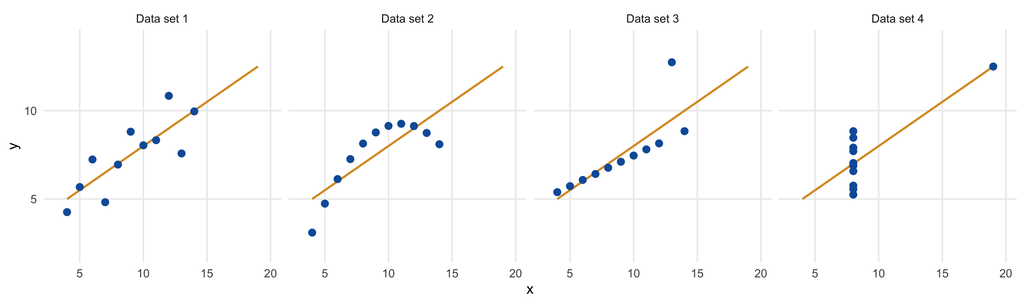

A noisy line, a perfect curve, a line with one outlier, a “relationship” created by a single point — **identical summary statistics**. Good description always uses **both** numbers and pictures.

Anscombe (1973), *The American Statistician* — built-in R data set `anscombe`.

## The data: tracks in the streaming charts

**~67,000 tracks** that appeared in the Spotify charts, with 31 variables:

| Group | Variables |
| --- | --- |
| Identifiers | `isrc`, `artist_id`, `artistName`, `trackName` |
| Chart performance | `streams`, `weeks_in_charts`, `n_regions`, `top10` |
| Audio characteristics (0–100) | `danceability`, `energy`, `speechiness`, `instrumentalness`, `liveness`, `valence` |
| Track properties | `tempo`, `song_length`, `song_age`, `explicit`, `release_date`, `genre`, `label` |
| Other platforms & reach | `youtube_views`, `tiktok_counts`, `shazam_counts`, `n_playlists`, artist-level followers & listeners |
| Expert judgment | `expert_rating` (poor – fair – good – excellent – masterpiece) |

# 2.2 Getting data into R

## Reading the data

```r
library(tidyverse)

music_url <- "https://raw.githubusercontent.com/WU-RDS/MA2025/main/data/music_data_fin.csv"
music_data <- read_csv2(music_url)
```

Why `read_csv2()` and not `read_csv()`? **What do you expect to happen** with `read_csv()`?

## An import can fail silently

```r
wrong_import <- read_csv(music_url)
dim(wrong_import)
```

```
[1] 66780     1
```

| Convention | Columns separated by | Decimal mark | Function |
| --- | --- | --- | --- |
| International | `,` | `.` | `read_csv()` |
| European | `;` | `,` | `read_csv2()` |

**No error ≠ correct.** Worse variants go unnoticed: `3,14` silently becoming `314`. Always **inspect right after importing**.

## A first look

```r
music_raw |>
  select(streams, danceability, genre, label, release_date, expert_rating) |>
  glimpse()
```

```
Rows: 66,796
Columns: 6
$ streams       <dbl> 11944813, 8934097, 38835, 46766, 2930573, 72199738, 1041694, 44363…
$ danceability  <dbl> 50.9, 35.3, 68.3, 70.4, 84.2, 35.2, 73.0, 55.6, 71.9, 34.6, 82.0, …
$ genre         <chr> "other", "Pop", "Pop", "HipHop/Rap", "HipHop/Rap", "Rock", "HipHop…
$ label         <chr> "Independent", "Universal Music", "Universal Music", "Independent"…
$ release_date  <date> 2016-06-20, 2018-06-14, 2018-04-26, 2020-03-31, 2020-02-07, 2004-…
$ expert_rating <chr> "excellent", "good", "good", "poor", "excellent", "fair", "poor", …
```

```r
summary(select(music_raw, streams, song_length))
```

```
    streams            song_length
 Min.   :      1003   Min.   : 0.01667
 1st Qu.:     55760   1st Qu.: 2.92925
 Median :    333336   Median : 3.33978
 Mean   :   7314674   Mean   : 3.43116
 3rd Qu.:   2181086   3rd Qu.: 3.81987
 Max.   :2165692479   Max.   :29.78383
```

## Other formats — same logic

| Format | Package | Function |
| --- | --- | --- |
| CSV (international / European) | readr | `read_csv()` / `read_csv2()` |
| Other delimiters | readr | `read_delim("file.txt", delim = "\t")` |
| Excel | readxl | `read_excel("file.xlsx", sheet = "Sheet1")` |
| SPSS / Stata | haven | `read_sav()` / `read_dta()` |
| Qualtrics export | qualtRics | `read_survey()` → group project |
| Web pages / APIs | rvest / jsonlite | see the course book *(optional)* |

Files in your project folder are read by their **relative path**: `read_excel("data/survey.xlsx")` — no `setwd()` needed inside an RStudio Project.

## What is a row?

**Tidy data** (Wickham, 2014):

1. Each **variable** is a column
2. Each **observation** is a row
3. Each **value** is a cell

Before any analysis, answer explicitly: **what does one row represent?** — the **unit of observation** (cf. “unit of analysis” in §1.8). Here: one row = one track. *Does that really hold?* → §2.5

**Untidy:** one column per month — “month” is hidden in the column names

| track | Jan | Feb | Mar |
| --- | --- | --- | --- |
| Track A | 120 | 135 | 150 |
| Track B | 80 | 70 | 65 |

**Tidy:** one row per track and month

| track | month | streams |
| --- | --- | --- |
| Track A | Jan | 120 |
| Track A | Feb | 135 |
| Track A | Mar | 150 |
| Track B | Jan | 80 |
| Track B | Feb | 70 |
| Track B | Mar | 65 |

# 2.3 Variables and levels of measurement

## Not every number is a quantity

| Level | Values express | Music data | Meaningful | Summary |
| --- | --- | --- | --- | --- |
| **Nominal** | Categories, no order | `genre`, `label`, `artist_id` | = / ≠ | Frequencies, mode |
| **Ordinal** | Ordered categories | `expert_rating` | + < / > | + median, quantiles |
| **Interval** | Equal distances, arbitrary zero | release *year*, °C | + differences | + mean, SD |
| **Ratio** | Equal distances, natural zero | `streams`, `song_length` | + ratios | + coefficient of variation |

Nominal + ordinal = **categorical**; interval + ratio = **continuous**. The level decides which **summaries**, **charts** — and later **tests** — are meaningful. The mean `artist_id` is as meaningless as the mean phone number.

## Your turn: classify these (2 min)

Nominal, ordinal, interval, or ratio?

1. Customer ID · (b) Satisfaction: “very dissatisfied” … “very satisfied” · (c) Price in € · (d) Payment method · (e) Year of first purchase · (f) Purchased (yes / no)

## Telling R the level of measurement

```r
music_data <- music_raw |>
  mutate(
    genre    = as.factor(genre),                                     # nominal
    explicit = factor(explicit, levels = c(0, 1),
                      labels = c("not explicit", "explicit")),        # nominal (binary)
    artist_id = as.character(artist_id),                             # an ID is not a number
    expert_rating = factor(expert_rating,
                           levels = c("poor", "fair", "good", "excellent", "masterpiece"),
                           ordered = TRUE)                           # ordinal
  )
```

```r
table(music_data$expert_rating)
```

```
       poor        fair        good   excellent masterpiece
       5356       13418       23243       23376        1403
```

As text, R would sort the ratings **alphabetically**; as an **ordered factor**, R knows that *good* lies between *fair* and *excellent*.

# 2.4 Data handling

## The verbs of data handling

| Verb | Does | Example question |
| --- | --- | --- |
| `filter()` | keeps **rows** meeting a condition | Pop tracks with > 10M streams? |
| `select()` | keeps **columns** | only artist, title, streams |
| `arrange()` | **sorts** rows | the most-streamed tracks? |
| `mutate()` | creates / changes **columns** | streams in millions? release year? |
| `group_by()` + `summarise()` | condenses to **one row per group** | median streams per label? |
| `count()` | counts rows per group | tracks per genre? |
| `left_join()` | **combines** tables via a key | add label information |

Same logic everywhere: data frame in → **column names without quotes** → data frame out. Chained with the pipe `|>`: *“and then”*.

## Chaining steps with the pipe

```r
music_data |>                                  # take the music data, then
  filter(genre == "Pop") |>                    # keep the pop tracks, then
  arrange(desc(streams)) |>                    # sort by streams, then
  select(artist, track, streams) |>            # keep three columns, then
  head(4)                                      # show the first four rows
```

```
# A tibble: 4 × 3
  artist                            track           streams
  <chr>                             <chr>             <dbl>
1 Ed Sheeran                        Shape of You 2165692479
2 Shawn Mendes feat. Camila Cabello Señorita     1156206588
3 XXXTENTACION                      SAD!         1103693478
4 Ed Sheeran                        Perfect      1045189446
```

## “… per …”: group_by() + summarise()

```r
music_data |>
  group_by(label) |>
  summarise(
    n_tracks       = n(),
    median_streams = median(streams),
    share_top10    = mean(top10 == "yes")
  )
```

```
# A tibble: 4 × 4
  label           n_tracks median_streams share_top10
  <fct>              <int>          <dbl>       <dbl>
1 Independent        22570        238884       0.0793
2 Sony Music         12390        355898.      0.113
3 Universal Music    21632        434943       0.113
4 Warner Music       10204        347152.      0.102
```

The workhorse of descriptive analysis: **every question of the form “… per …”** has this shape.

## Combining tables: left_join()

```r
label_info <- tibble(
  label      = c("Universal Music", "Sony Music", "Warner Music", "Independent"),
  label_type = c("Major", "Major", "Major", "Independent")
)
music_data <- music_data |> left_join(label_info, by = "label")
music_data |> count(label_type)
```

```
# A tibble: 2 × 2
  label_type      n
  <chr>       <int>
1 Independent 22570
2 Major       44226
```

Keeps **all rows of the left table**; no match → `NA`. **Check the row count after every join** — a non-unique key duplicates rows silently.

## Your turn (live coding, 8 min)

Using the verbs, answer:

1. How many **hip-hop** tracks reached the **top 10**?
2. Which **label** has the highest **median streams** among hip-hop tracks?
3. Create a variable `streams_mio` (streams in millions) and show the five **rock** tracks with the most streams.

# 2.5 Not trusting your data too early

## Five checks before you trust a data set

1. **Did the import work?** Rows, columns, types — §2.2
2. **Missing values** — including zeros that mean “unknown”
3. **Impossible values** — ranges, dates, units
4. **Duplicates** — is the identifier really unique?
5. **Extreme values** — errors or information?

…and one question beyond the checks: **how did the data come to be?**

## Check 2: zeros that mean “unknown”

```r
sum(is.na(music_data))                              # missing values: none at all?
```

```
[1] 0
```

```r
mean(music_data$youtube_views == 0)                 # share of tracks with 0 YouTube views
```

```
[1] 0.5796155
```

58% of charting tracks with **zero** YouTube views? Almost certainly **“no data”**, not “no views”. **Disguised missing values** (revenue 0 for never-contacted customers, age 0 in the CRM) drag every average down. Recode: `na_if(youtube_views, 0)` — and report how many are missing.

## Check 3: impossible values

```r
music_data |>
  summarise(first_release = min(release_date), last_release = max(release_date),
            min_length = min(song_length), max_length = max(song_length),
            min_tempo = min(tempo))
```

```
# A tibble: 1 × 5
  first_release last_release min_length max_length min_tempo
  <date>        <date>            <dbl>      <dbl>     <dbl>
1 1942-01-01    2029-04-06       0.0167       29.8         0
```

Releases in **2029**, a **1-second** song, a tempo of **0 bpm**. Some values are clearly errors, others merely unusual (intros, medleys) — **inspect individually** before deciding.

## Check 4: what is a row, really?

```r
music_data |> summarise(n_rows = n(), n_distinct_isrc = n_distinct(isrc))
```

```
# A tibble: 1 × 2
  n_rows n_distinct_isrc
   <int>           <int>
1  66796           56945
```

The ISRC should identify a recording uniquely — yet there are **9,851 more rows than ISRCs**, and the rows differ in streams and chart weeks. Versions? Periods? Errors? Without documentation we cannot tell — but “one row = one recording” **does not hold**.

## Check 5: outliers are not always errors

```r
music_data |> arrange(desc(streams)) |> select(artist, track, streams) |> head(4)
```

```
# A tibble: 4 × 3
  artist        track                streams
  <chr>         <chr>                  <dbl>
1 Ed Sheeran    Shape of You      2165692479
2 Tones and I   Dance Monkey      1909947000
3 Billie Eilish bad guy           1459149566
4 Lewis Capaldi Someone You Loved 1419867299
```

In markets for creative products, **a few hits account for a large share of consumption**. Here, the extremes are the story — check them, don’t delete them.

**Document, don’t silently delete:** corrections in **code**, **explicit** flags instead of overwriting, **transparent** reporting of what changed.

## How did the data come to be?

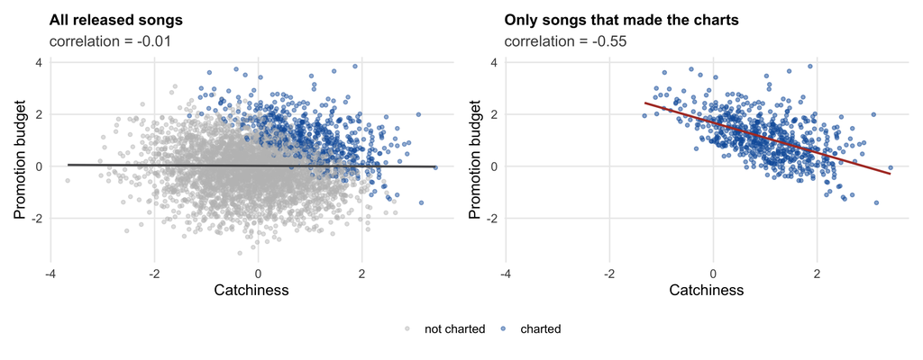

Only **charted** tracks are in the data. Catchiness and promotion are unrelated among all songs (left) — but **negatively related among the survivors** (right). Created purely by the selection.

## Survivorship is everywhere in marketing data

- Successful **products** only (launch data of products still on the market)
- **Customers who did not churn** (loyalty-program data)
- **Companies that still exist** (“what do successful firms do?”)
- **Survey respondents** — who chooses to answer is itself a choice (→ your group project!)

Add one question to every descriptive checklist: **who is *not* in my data — and why?** Relationships among the survivors can differ from those in the population you care about (*Berkson’s paradox*).

# 2.6 Summarizing data

## Categorical variables: frequencies

```r
music_data |>
  count(genre, sort = TRUE) |>
  mutate(share = n / sum(n)) |>
  head(5)
```

```
# A tibble: 5 × 3
  genre             n  share
  <fct>         <int>  <dbl>
1 Pop           30069 0.450
2 HipHop/Rap    21131 0.316
3 other          5228 0.0783
4 Rock           4214 0.0631
5 Electro/Dance  2703 0.0405
```

## Conditional frequencies

```r
music_data |>
  group_by(genre) |>
  summarise(n = n(), share_top10 = mean(top10 == "yes")) |>
  arrange(desc(share_top10))
```

```
# A tibble: 11 × 3
   genre             n share_top10
   <fct>         <int>       <dbl>
 1 Country         504      0.264
 2 other          5228      0.194
 3 R&B            1881      0.172
 4 Electro/Dance  2703      0.142
 5 Soundtrack      326      0.138
 6 Reggae          121      0.116
 7 HipHop/Rap    21131      0.0974
 8 Pop           30069      0.0788
 9 Rock           4214      0.0743
10 German Folk     539      0.0519
11 Classics/Jazz    80      0.0125
```

Beware of **small groups**: a share computed from 80 tracks is far less reliable than one from 30,000 — made precise in Module 3.

## Mean or median?

```r
music_data |>
  summarise(mean = mean(streams), median = median(streams),
            q25 = quantile(streams, 0.25), q75 = quantile(streams, 0.75))
```

```
# A tibble: 1 × 4
      mean  median   q25      q75
     <dbl>   <dbl> <dbl>    <dbl>
1 7314674. 333336. 55760 2181086.
```

“The average track has **7.3 million** streams.” — Is this a good description of the typical track?

No: a few mega-hits pull the mean up — the distribution is **right-skewed**. The **median** (~333,000) describes the typical track. Mean far above median → a few extremes dominate the average (sales, revenue, followers, streams).

## Location, dispersion, shape — in one call

```r
library(psych)
music_data |>
  select(streams, danceability, energy, valence, song_length) |>
  describe() |>
  select(n, mean, sd, median, min, max, skew)
```

```
                 n       mean          sd    median     min           max  skew
streams      66796 7314673.94 39956263.68 333335.50 1003.00 2165692479.00 16.74
danceability 66796      66.32       14.71     68.00    0.00         98.30 -0.53
energy       66796      64.37       17.52     66.10    0.00        100.00 -0.54
valence      66796      50.42       22.26     50.00    0.00         99.00  0.08
song_length  66796       3.43        0.86      3.34    0.02         29.78  3.36
```

- **Location:** mean, median
- **Dispersion:** SD, range, IQR, coefficient of variation (SD / mean)
- **Shape:** skewness — `streams` ≈ 17: extremely right-skewed

**z-scores** express relative position: $z = (x - \bar{x}) / s$ → “1.5 SDs above the average track”. Their link to probabilities: Module 3.

# 2.7 Visualizing data

## The grammar of graphics

Every `ggplot2` chart is built from the same components, **layer by layer** with `+`:

1. **Data** — `ggplot(music_data, …)`
2. **Aesthetic mappings** — `aes(x = …, y = …, color = …)`
3. **Geoms** — `geom_col()`, `geom_point()`, `geom_boxplot()`, …
4. **Labels, scales, themes** — `labs()`, `scale_…()`, `theme_…()`

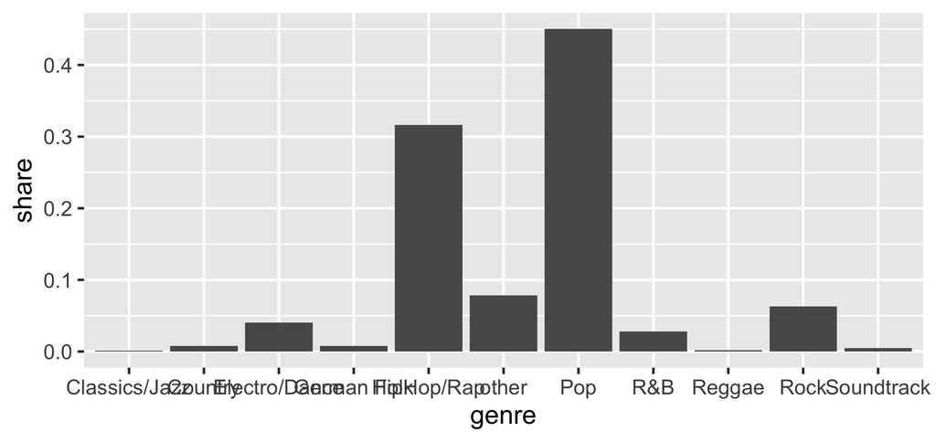

```r
genre_shares <- music_data |>
  count(genre) |> mutate(share = n / sum(n))
ggplot(genre_shares, aes(x = genre, y = share)) +
  geom_col()
```

## From default to useful

```r
ggplot(genre_shares,
       aes(x = fct_reorder(genre, share), y = share)) +
  geom_col(fill = "#0f5da8") +
  geom_text(aes(label = scales::percent(share, accuracy = 0.1)),
            hjust = -0.15, size = 3.5) +
  coord_flip() +
  scale_y_continuous(labels = scales::percent,
                     limits = c(0, 0.5)) +
  labs(x = NULL, y = "Share of tracks",
       title = "Pop and hip-hop dominate the charts") +
  theme_minimal()
```

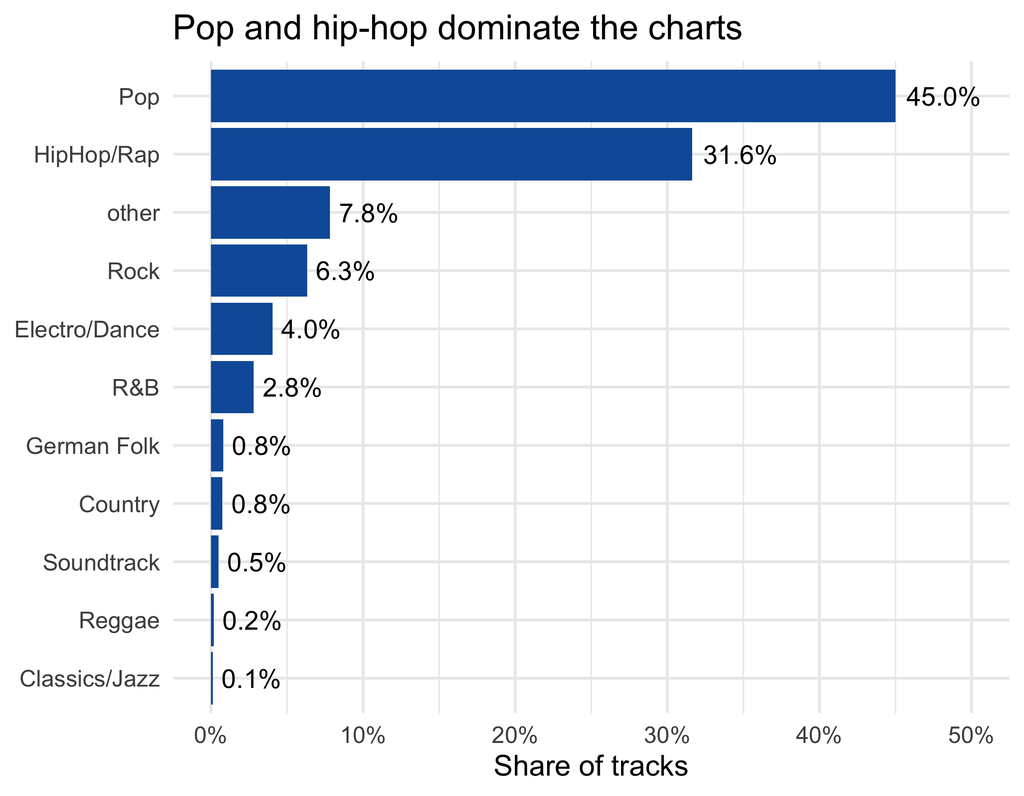

Sorted bars · readable labels · percent axis · a title that **states the finding**, not the topic.

## Which chart for which variables?

| To show … | Variables | Chart | geom |
| --- | --- | --- | --- |
| One distribution | categorical | Bar chart | `geom_bar()` / `geom_col()` |
|  | continuous | Histogram, density, boxplot | `geom_histogram()`, `geom_density()`, `geom_boxplot()` |
| Groups compared | categorical × continuous | Boxplots, jittered points | `geom_boxplot()`, `geom_jitter()` |
| A relationship | continuous × continuous | Scatter plot | `geom_point()` |
| Two categoricals | categorical × categorical | Grouped / stacked bars of shares | `geom_col(position = "dodge")` |
| Change over time | time × continuous | Line chart | `geom_line()` |

A third variable: **color** (`aes(color = …)`) or **small multiples** (`facet_wrap(~ …)`).

## Skewed data: the log scale

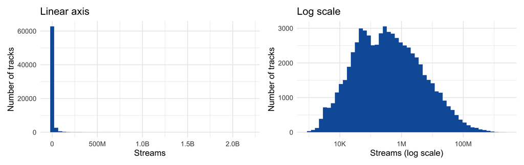

On a log scale, each step **multiplies** (10K → 100K → 1M). Makes skewed distributions readable — **always label it** in the axis title.

## Comparing groups: boxplots

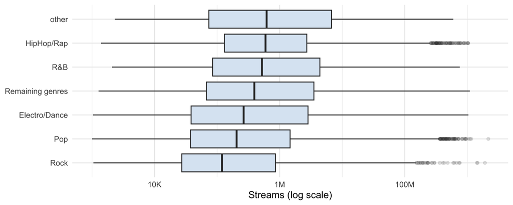

## Charts are data-quality tools, too

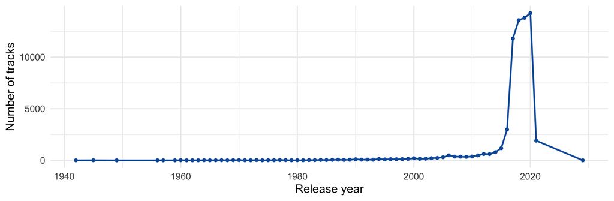

Two things in this chart should make you suspicious. **Which?**

## Honest visualization I: bars start at zero

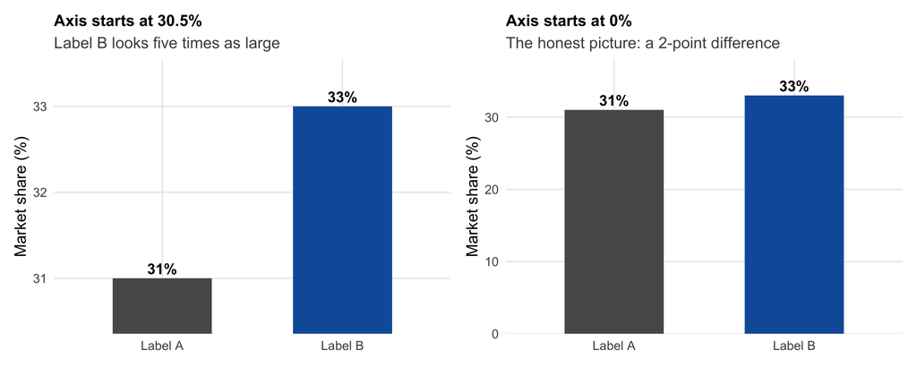

Bars encode values by **length** — a truncated axis makes the lengths lie. (Points and lines encode by *position* and may start elsewhere — clearly labeled.)

## Honest visualization II: dual axes

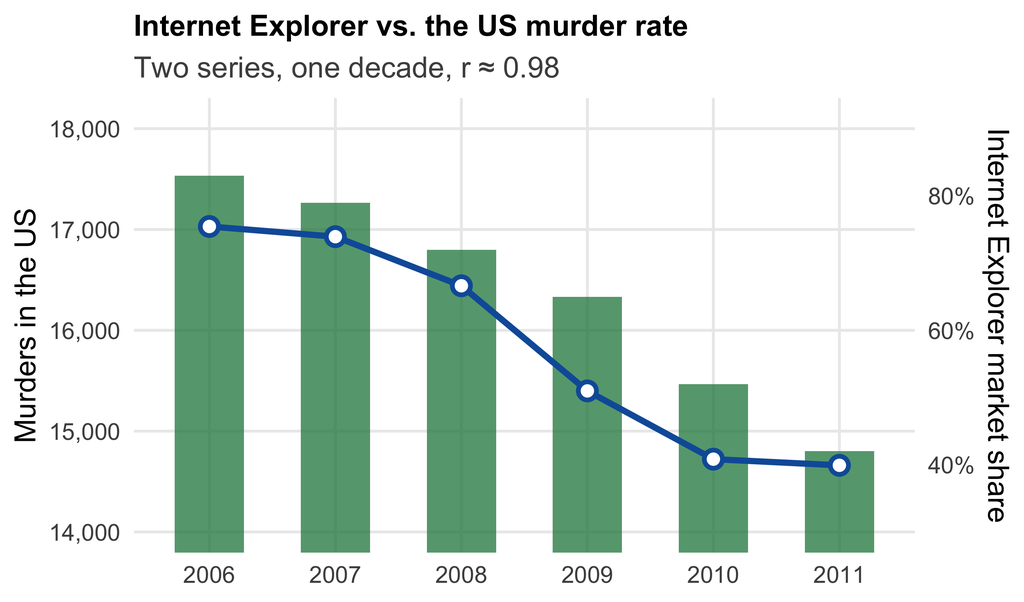

Remember this one from §1.4?

Two independently chosen y-axes let you make **almost any two series look related**. Alternatives: index both series (first year = 100), or two charts side by side.

- Also avoid: **3D effects**, **pies** with many slices, colors without meaning, unsorted categories, axes without units

# 2.8 From description to insight

## “Do explicit tracks perform worse?”

```r
music_data |>
  group_by(explicit) |>
  summarise(n = n(), median_streams = median(streams))
```

```
# A tibble: 2 × 3
  explicit         n median_streams
  <fct>        <int>          <dbl>
1 not explicit 58603         385290
2 explicit      8193          93600
```

Can we write *“explicit lyrics reduce streams”*? **What would you check first?**

## Looking within genres

```r
music_data |>
  mutate(genre = fct_lump_n(genre, n = 5, other_level = "Remaining genres")) |>
  group_by(genre) |>
  summarise(share_explicit      = mean(explicit == "explicit"),
            median_not_explicit = median(streams[explicit == "not explicit"]),
            median_explicit     = median(streams[explicit == "explicit"]))
```

```
# A tibble: 6 × 4
  genre            share_explicit median_not_explicit median_explicit
  <fct>                     <dbl>               <dbl>           <dbl>
1 Electro/Dance            0.340              494986.           72608
2 HipHop/Rap               0.0515             618344.          226571
3 other                    0.0779             704424           133351
4 Pop                      0.155              236848.           87798
5 Rock                     0.172              159262.           31128
6 Remaining genres         0.112              536213           224444
```

The gap persists within each large genre — but its size **and the share of explicit tracks** vary strongly. Genre, label, artist popularity, and the selection into the charts are all candidate **confounders** (§1.5).

## What we can — and cannot — write

**Descriptive ✓**

*“Among the tracks in our chart data, those with explicit lyrics have a lower median number of streams than those without (about 94,000 vs. 385,000). The gap is visible within each large genre, but varies in size.”*

**Causal ✗**

*“Explicit lyrics reduce streams.”*

That would require comparing the **same** tracks with and without explicit lyrics — a counterfactual the data cannot provide (§1.2).

A good descriptive finding answers: **What** was measured? **How much** (numbers, not adjectives)? **Compared to what? For whom? With which caveat?** — and uses descriptive verbs: *is higher, differs, is associated with* — not *causes, drives, increases*.

## Assignment 1: data handling & description

- **Your own data set** (individual) — import, check, handle, summarize, visualize
- Submit as a **reproducible report** (.Rmd → HTML) via Canvas
- **Deadline:** Group A: Mon, Oct 26 · Group B: Wed, Oct 28
- **Debrief:** 3 short paper questions about *your* results at the start of session 4

Everything you need is in **this chapter**. AI assistants welcome — you must be able to **explain every line** you submit.

## Learning check

1. After `read_csv("file.csv")` on a file from a German Excel, the data frame has **one column**. Why — and what should you use instead?
2. Mean revenue per customer: **€480**, median: **€95**. What does this tell you about the distribution? Which number describes the typical customer?
3. A loyalty-program data set contains **only active customers**. Among them, those who received few discounts buy most often. Why might this pattern mislead?
4. **True or false?** (a) A variable stored as a number can be nominal. (b) Outliers should always be removed. (c) The y-axis of a bar chart should start at zero. (d) A zero in a data set always means the quantity was zero.

## Next session

**Module 3 · Uncertainty & Experiments I** — *How sure can I be?*

- Why every number from a sample is uncertain — and how to quantify it
- Standard errors and confidence intervals — by simulation
- Our first experiment analysis: comparing two groups

Course book chapter 2 (consolidation reading for today) is online — with all code from these slides. **Assignment 1** is on Canvas.